# DasyMapR - Ένας οδηγός για την χρήση του πακέτου

Τσακλάνος Βαγγέλης

2016-06-04

## Το πακέτο DasyMapR

Το πακέτο της R που αναπτύχθηκε περιέχει μία σειρά εργαλείων με σκοπό την υλοποίηση δασυμετρικών χαρτών με την μέθοδο του επιμερισμού των δεδομένων στον κανονικό ETRS-LAEA κάναβο. Πληροφορίες για τον γεωγραφικό κανάβο μπορούν να βρεθούν [INSPIRE Specification on Geographical Grid Systems](http://inspire.ec.europa.eu/index.cfm/pageid/241/documentid/3390)

## Τι περιέχεται σε αυτό το κείμενο

- Εγκατάσταση του πακέτου
- Τι υπάρχει στο πακέτο
- Φόρτωση Δεδομένων
- Απόδοση τιμής στο κελί - Κατηγορικά(ποιοτικά) Δεδομένα - MaxArea
- Απόδοση τιμής στο κελί - Αριθμητικά (ποσοτικά) Δεδομένα - PropCal
- Επιφάνεια Πηγή
- Βοηθητική Επιφάνεια
- Οι δασυμετρικοί υπολογισμοί
- Η Δασυμετρική επιφάνεια σε Βοηθητική

## Εγκατάσταση

Το πακέτο δεν φιλοξενείται στο CRAN (θα χρειαστεί πολλή δουλειά ακόμη για αυτό) αλλά στο προσωπικό αποθετήριο του σπουδαστή στο github. Για να εγκατασταθεί το `DasyMapR` θα πρέπει καταρχήν να εγκατασταθεί το πακέτο `devtools` και στην συνέχεια με την χρήση της συνάρτησης `install_github()` να γίνει η εγκατάσταση του πακέτου

```r
install.packages("devtools")
library(devtools)
install_github("etsakl/DasyMapR", build_vignettes = TRUE)
library(DasyMapR)
```

## DasyMapR τι περιέχεται

Το πακέτο αποτελείται αποτελείται από από `S4 - Classes` από τις μεθόδους τους `methods`, την τεκμηρίωσή τους `files.Rd` και τα δεδομένα `data` που θα χρησιμοποιηθούν σε αυτό το κείμενο με την τεκμηρίωσή τους και το ίδιο το κείμενο ως `vignette` που επίσης συνοδεύει το πακέτο.

```r
library(DasyMapR)
library(knitr)
DasyMapR.contains <- sort(ls("package:DasyMapR"))
kable(as.data.frame(DasyMapR.contains))
```

## DasyMapR.contains

ActuallVal2Density  
CLC2000.ARGOLIDA.RES  
CLC2000_CODES  
CLC2000_GEO_CODES  
CORINE2000_CODES  
CheckEtrsResolution  
CheckEtrsValidity  
CreateEtrsVectorGrid  
DASY_GPD  
ETRS  
EtrsAncillarySurface  
EtrsCellCodes  
EtrsCells  
EtrsCheckCodeColumns  
EtrsDasymetricSurface  
EtrsGrid  
EtrsPoints  
EtrsSourceSurface  
EtrsSurface  
EtrsTableCodes  
EtrsTransform  
GEOSTAT_grid_EU_POP_2006_1k_V1_1_1 NUTS3_OCMG  
NUTSV9_LEAC  
NUTSV9_LEAC_GR_1km_grided  
NUTS_2013_01M_EL  
etrsAncillarySurface  
etrsAncillarySurface.default  
etrsCellCenter  
etrsCells  
etrsCells.default  
etrsDasymetric2Ancillary  
etrsDasymetric2Raster  
etrsGrid  
etrsGrid.default  
etrsGrid2Spdf  
etrsMaxArea  
etrsPoint2Grid  
etrsPoints  
etrsPoints.default  
etrsPropValue  
etrsPropWeightedValue  
etrsReverseCellCode  
etrsSourceSurface  
etrsSourceSurface.default  
etrsSourceSurfacePar  
etrsSurface  
etrsSurface.default  
etrsSurface2Spdf  
etrsSurfacePar  
joinMaxAreaSurfaceDataFrames  
nama_10r_3gdp  
oikismoi  
validity

Περισσότερες πληροφορίες για το πακέτο θα μπορούσε να βρει κάποιος στα file του πακέτου `help("DasyMapR")` ή στο [github](https://github.com/etsakl/DasyMapR.git)

## Φόρτωση Δεδομένων

Το πακέτο συνοδεύεται από κάποια δεδομένα κατά κανόνα *ανοικτά δημόσια δεδομένα* που η προσπάθεια για να συμβάλλουμε στην αξιοποίηση τους έγινε και η αφορμή για ανάπτυξη του συγκεκριμένου πακέτου που σκοπεύει να συμβάλει στην οπτικοποίηση και ανάλυσή τους. Προφανώς για λόγους οικονομίας χρόνου μεταφόρτωσης και αποθηκευτικού χώρου τα δεδομένα αυτά είναι υποσύνολα των δεδομένων που προσφέρονται από τους οργανισμούς που τα διαθέτουν. Τεκμηρίωση και πληροφορίες υπάρχουν στα help files του πακέτου help(“DasyMapR”)` ή στο [github](https://github.com/etsakl/DasyMapR.git)

```r
# Αν τρέξει ο κώδικας παρουσιάζονται τα διαθέσιμα δεδομένα
DasyMapR.data <- data(package = "DasyMapR")
print(DasyMapR.data)
```

Θα φορτώσουμε τα δεδομένα που μεταμορφώθηκαν από το [GeoData.open.gov](http://geodata.gov.gr/dataset/oria-nomon-okkhe) και θα επιλέξουμε τους νομούς της περιφέρειας Πελοποννήσου για τους δασυμετρικούς μας υπολογισμούς.

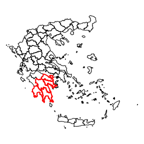

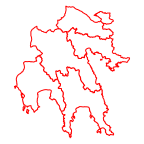

```r
# Φόρτωσε τα δεδομένα
data("NUTS3_OCMG")
# Δίάλεξε κάποια
pp <- c("Ν. ΑΡΓΟΛΙΔΟΣ", "Ν. ΚΟΡΙΝΘΙΑΣ", "Ν. ΑΡΚΑΔΙΑΣ",
    "Ν. ΜΕΣΣΗΝΙΑΣ", "Ν. ΛΑΚΩΝΙΑΣ")
Π.ΠΕΛΟΠΟΝΝΗΣΟΥ <- NUTS3_OCMG[which(!is.na(match(NUTS3_OCMG[["NAME"]],
    pp))), ]
par(mar = c(0.1, 0.1, 0.1, 0.1))
# και σχεδίασε τα
plot(NUTS3_OCMG)
plot(Π.ΠΕΛΟΠΟΝΝΗΣΟΥ, border = 2, lwd = 2, add = T)
plot(Π.ΠΕΛΟΠΟΝΝΗΣΟΥ, border = 2, lwd = 2)
```

ας δούμε και τα περιγραφικά δεδομένα των νομών που περιέχει το αρχείο.

```r
# Τα περιγράφικά σε πίνακα
kable(head(Π.ΠΕΛΟΠΟΝΝΗΣΟΥ@data[, 3:10]))
```

|  | NAME | POP91 | EKTASH | PYKNOTHTA | pl2001 | Plwomen01 | Plman01 | metaboli |
| --- | --- | --- | --- | --- | --- | --- | --- | --- |
| 13 | Ν. ΜΕΣΣΗΝΙΑΣ | 166964 | 2995.27 | 55.7426 | 166566 | 82556 | 84010 | -0.0023838 |
| 16 | Ν. ΛΑΚΩΝΙΑΣ | 95696 | 3631.73 | 26.3500 | 92811 | 45310 | 47501 | -0.0301476 |
| 23 | Ν. ΑΡΓΟΛΙΔΟΣ | 97636 | 2157.00 | 45.2647 | 102392 | 50308 | 52084 | 0.0487115 |
| 25 | Ν. ΑΡΚΑΔΙΑΣ | 105309 | 4423.48 | 23.8068 | 91326 | 43826 | 47500 | -0.1327810 |
| 41 | Ν. ΚΟΡΙΝΘΙΑΣ | 141823 | 2297.75 | 61.7226 | 144527 | 71771 | 72756 | 0.0190660 |

## Κατηγορικά Δεδομένα - Η χρήση της MaxArea

Η Νομοί έχουν ένα ποιοτικό χαρακτηριστικό αυτό της “Ονομασίας” `Π.ΠΕΛΟΠΟΝΝΗΣΟΥ[["ΝΑΜΕ"]]` που τους προσδίδει την ιδιότητα του Νομού (περιοχή διοικητικής διαίρεσης). Θα ήταν χρήσιμο αυτή η ιδιότητα να αποδοθεί στα κελιά του κανάβου αφού με βάση αυτή την ιδιότητα στη συνέχεια θα μπορούσαν να του π.χ. αποδοθούν και άλλα χαρακτηριστικά που έχουν ως επιφάνεια απαρίθμησης, αυτή ακριβώς την ιδιότητα δηλαδή του νόμου. Το κελί σε αυτήν την περίπτωση των κατηγορικών δεδομένων παίρνει την τιμή της επιφάνειας που καταλαμβάνει το μεγαλύτερο μέρος του κελιού. Η μέθοδος `etrsSurface` που δέχεται ορίσματα την επιφάνεια `input.surface` την μέθοδο `Max.Area` και το μέγεθος του κελιού `cell.size`. Θα πρέπει να αναφερθεί εδώ ότι η επιφάνεια `NUTS3_OCMG` είναι σε σύστημα συντεταγμένων [ΕΓΣΑ87](http://spatialreference.org/ref/epsg/2100/)(GGRS’87 (EPSG:2100)) όμως τα αποτελέσματα δηλαδή η τελικά υπολογιζόμενη etrsSurface θα έχει πλέον σύστημα αναφοράς το [ETRS-LAEA](http://spatialreference.org/ref/epsg/etrs89-etrs-laea/) καλώντας κατά τους υπολογισμούς την `DasyMapR::etsrTransform()` του πακέτου και στέλνει μήνυμα `warning` ενημερώνοντας για την μετατροπή.

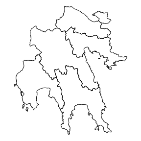

[figure not shown]

```r
library(DasyMapR)
# Καλεί την EtrsTransForm
srf.grd.max <- etrsSurface(input.surface = Π.ΠΕΛΟΠΟΝΝΗΣΟΥ, over.method.type = "MaxArea",
    cell.size = 10000)
plot(Π.ΠΕΛΟΠΟΝΝΗΣΟΥ)
plot(srf.grd.max)
```

Το αντικείμενο που δημιουργήθηκε δηλαδή `srf.grd.max` είναι αντικείμενο κλάσης `EtrsSurface` και τα περιγραφικά δεδομένα στο `slot` (`@data`) είναι σε μορφή πίνακα :

```r
kable(head(srf.grd.max@data))
```

|  | CELLCODE | EASTOFORIGIN | NORTHOFORIGIN | FEATURE |
| --- | --- | --- | --- | --- |
| 10kmE543N158 | 10kmE543N158 | 5430000 | 1580000 | 16 |
| 10kmE543N159 | 10kmE543N159 | 5430000 | 1590000 | 16 |
| 10kmE549N159 | 10kmE549N159 | 5490000 | 1590000 | 16 |
| 10kmE538N160 | 10kmE538N160 | 5380000 | 1600000 | 13 |
| 10kmE543N160 | 10kmE543N160 | 5430000 | 1600000 | 16 |
| 10kmE548N160 | 10kmE548N160 | 5480000 | 1600000 | 16 |

Όπως φαίνεται στο πίνακα τα στοιχεία που περιέχονται είναι ο κωδικός `$CELLCODE`του κελιού οι συντεταγμένες του κάτω άκρου του κελιού `$EASTOFORIGIN,$NORTHOFORIGIN"` και ο αριθμός αναγνώρισης της επιφάνειας `$FEATURE` από την οποία έχει πάρει την ιδιότητα το κελί. Ο κωδικός του κελιού που επαναλαμβάνεται στην αρχή είναι η ιδιότητα `row.names()` του `data.frame` `@data` και χρησιμεύει ως αναγνωριστικό σύνδεσης με το γεωμετρικό μέρος του αντικείμενου. (`@polygons`). Περισσότερες πληροφορίες για την δομή του αντικειμένου `EtrsSurface` αλλά και του `SpatialPolygonsDataFrame` παρέχονται στο κυρίως κείμενο και στα help files.

Θα ήταν χρήσιμο να συμπεριλάβει κάποιος ιδιότητες από τα περιγραφικά δεδομένα της επιφάνειας πηγής στο πίνακα δεδομένων των κελιών. H μέθοδος `DasyMapR::joinMaxAreaSurfaceDataFrame` μπορεί να κληθεί και να συνενώσει τα χαρακτηριστικά που δεν έχουν συμπεριληφθεί αρχικά ως ιδιότητες της νέας επιφάνειας (του κανάβου).

```r
srf.grd.max.full <- joinMaxAreaSurfaceDataFrames(the.surface = NUTS3_OCMG, the.EtrsSurface = srf.grd.max)
kable(head(srf.grd.max.full@data[, c(7:12)]))
```

|  | NAME | POP91 | EKTASH | PYKNOTHTA | pl2001 | Plwomen01 |
| --- | --- | --- | --- | --- | --- | --- |
| 10kmE538N162 | Ν. ΜΕΣΣΗΝΙΑΣ | 166964 | 2995.27 | 55.7426 | 166566 | 82556 |
| 10kmE538N160 | Ν. ΜΕΣΣΗΝΙΑΣ | 166964 | 2995.27 | 55.7426 | 166566 | 82556 |
| 10kmE538N163 | Ν. ΜΕΣΣΗΝΙΑΣ | 166964 | 2995.27 | 55.7426 | 166566 | 82556 |
| 10kmE539N163 | Ν. ΜΕΣΣΗΝΙΑΣ | 166964 | 2995.27 | 55.7426 | 166566 | 82556 |
| 10kmE536N162 | Ν. ΜΕΣΣΗΝΙΑΣ | 166964 | 2995.27 | 55.7426 | 166566 | 82556 |
| 10kmE537N162 | Ν. ΜΕΣΣΗΝΙΑΣ | 166964 | 2995.27 | 55.7426 | 166566 | 82556 |

Κάτι που πρέπει να επισημανθεί εδώ είναι ότι ο χρήστης πρέπει πάντα να έχει υπόψη του τι δεδομένα έχει και τι αναγωγές πρέπει να κάνει για να έχει ορθά αποτελέσματα. Για παράδειγμα στον τελευταίο πίνακα στο κελί ως τιμές του πληθυσμού εμφανίζονται οι `$POP91` ή `$pl2001`. Αυτό είναι λάθος διότι η τιμές αυτές αναφέρονται στις αρχικές επιφάνειες απαριθμήσεις δηλαδή στους νομούς. Ακόμη και η τιμή της πυκνότητας ανά κελί είναι εσφαλμένη αφού δεν έχουν γίνει κατάλληλες αναγωγές.

Ο χρόνος που χρειάζεται για να γίνουν οι υπολογισμοί μπορούν να μειωθεί με την χρήση της μεθόδου `DasyMapR::etrsSurfacePar()` όπου γίνεται χρήση περισσοτέρων πόρων του συστήματος (επεξεργαστών και πυρήνων) με την χρήση των πακέτων `foreach` και `doParaller` της R. Περισσότερες πληροφορίες για αυτό μπορούν να βρεθούν στο κυρίως κείμενο.

## Αριθμητικά (ποσοτικά) Δεδομένα - Η χρήση της PropCal

Για την καλύτερη παρακολούθηση του παραδείγματος και κάνοντας χρίση των ίδιων δεδομένων που αντλήσαμε από το [GeoData.open.gov](http://geodata.gov.gr/dataset/oria-nomon-okkhe) θα κρατήσουμε μόνο τις στήλες που είναι χρήσιμες για το τρέχον παράδειγμά.

```r
# Θα κρατήσουμε μόνο τον πλυθισμό του 2001
Π.ΠΕΛΟΠΟΝΝΗΣΟΥ.2001 <- Π.ΠΕΛΟΠΟΝΝΗΣΟΥ[, c(3, 7)]
kable(Π.ΠΕΛΟΠΟΝΝΗΣΟΥ.2001@data)
```

|  | NAME | pl2001 |
| --- | --- | --- |
| 13 | Ν. ΜΕΣΣΗΝΙΑΣ | 166566 |
| 16 | Ν. ΛΑΚΩΝΙΑΣ | 92811 |
| 23 | Ν. ΑΡΓΟΛΙΔΟΣ | 102392 |
| 25 | Ν. ΑΡΚΑΔΙΑΣ | 91326 |
| 41 | Ν. ΚΟΡΙΝΘΙΑΣ | 144527 |

Η τιμή στόχος που θέλουμε να επιμερίσουμε στον κάναβο είναι αυτή του πληθυσμού. Αν επιμερίσουμε αυτή την τιμή του χαρακτηριστικού `pl$2001` θα αποδώσουμε στο κελί λανθασμένη τιμή (όπως προαναφέρθηκε) . Θα πρέπει να μετατραπεί από απόλυτη τιμή σε πυκνότητα πληθυσμού. Στο πακέτο έχει αναπτυχθεί η μέθοδος ():`DasyMapR::ActullVal2Density()` που θα κάνει την μετατροπή

```r
Π.ΠΕΛΟΠΟΝΝΗΣΟΥ.2001 <- ActuallVal2Density(input.surface = Π.ΠΕΛΟΠΟΝΝΗΣΟΥ.2001,
    surface.value.col = 2, area.unit = 1e+06)
kable(Π.ΠΕΛΟΠΟΝΝΗΣΟΥ.2001@data)
```

|  | NAME | pl2001 | AREA | VALUE |
| --- | --- | --- | --- | --- |
| 13 | Ν. ΜΕΣΣΗΝΙΑΣ | 166566 | 2995.265 | 55.6098 |
| 16 | Ν. ΛΑΚΩΝΙΑΣ | 92811 | 3631.734 | 25.5556 |
| 23 | Ν. ΑΡΓΟΛΙΔΟΣ | 102392 | 2157.004 | 47.4696 |
| 25 | Ν. ΑΡΚΑΔΙΑΣ | 91326 | 4423.483 | 20.6457 |
| 41 | Ν. ΚΟΡΙΝΘΙΑΣ | 144527 | 2297.754 | 62.8993 |

Η τιμή `$VALUE` πλέον αναφέρεται σε κατοίκους/km<sup>2</sup> και εκφράζει πυκνότητα. Το `@data$VALUE` (slot) πλέον περιέχει και την τιμή του εμβαδού σε km<sup>2</sup>.

Θα επιμερίσουμε την τιμή με την χρήση της μεθόδου `etrsSourceSurface()` για την τιμή (`VALUE`) της πυκνότητας Η μέθοδος που είναι καταλληλότερη για τον υπολογισμό της τιμής του κελιού μετά την προβολή της επιφάνειας θα είναι αυτή του αναλογικού υπολογισμού σε σχέση με την επιφάνεια $CELLVALUE = (V~i~ ∗ Share~i~)$ όπου V<sub>i</sub>, η τιμή της επιφάνειας και Share<sub>i</sub>, το μερίδιο της επιφάνειας i μέσα στο κελί

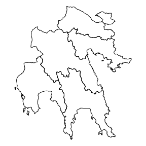

[figure not shown]

```r
srf.grd.prop <- etrsSourceSurface(input.surface = Π.ΠΕΛΟΠΟΝΝΗΣΟΥ.2001,
    over.method.type = "PropCal", surface.value.col = 4, cell.size = 10000)
par(mar = c(0.1, 0.1, 0.1, 0.1))
plot(Π.ΠΕΛΟΠΟΝΝΗΣΟΥ)
plot(srf.grd.prop)
```

Το αντικείμενο που δημιουργήθηκε είναι αντικείμενο της κλάσης `EtrsSourceSurface` και ο πίνακας που είναι συσχετισμένος με την επιφάνεια περιεχέι τα χαρακτηριστικά

```r
kable(head(srf.grd.prop@data))
```

|  | CELLCODE | EASTOFORIGIN | NORTHOFORIGIN | CELLVALUE |
| --- | --- | --- | --- | --- |
| 10kmE543N157 | 10kmE543N157 | 5430000 | 1570000 | 0.7308902 |
| 10kmE544N157 | 10kmE544N157 | 5440000 | 1570000 | 5.8726769 |
| 10kmE543N158 | 10kmE543N158 | 5430000 | 1580000 | 18.1751427 |
| 10kmE544N158 | 10kmE544N158 | 5440000 | 1580000 | 10.2094622 |
| 10kmE548N158 | 10kmE548N158 | 5480000 | 1580000 | 3.1382277 |
| 10kmE549N158 | 10kmE549N158 | 5490000 | 1580000 | 3.0538942 |

Λεπτομέρειες για τον υπολογισμό της `$CELLVALUE` μπορεί κάποιος να βρει αν φορτώσει το **προσωρινό αρχείο** με όνομα **“.surface.detailed.table.rds”** που αποθηκεύετε στο working directory. Για το παράδειγμα της συγκεκριμένης εργασίας φορτώνουμε το εν λόγω αρχείο (.rds) και εμφανίζουμε ορισμένες γραμμές του.Σε αυτές εμφανίζονται οι τιμές για τμήμα του κελιού πριν την άθροιση και τον τελικό υπολογισμό (για αυτό και εμφανίζονται `row.names(srf.grd.prop@data)` με την προσθήκη αριθμού ώστε να είναι μοναδικός ο κωδικός αριθμός `ID`.

```r
wd <- getwd()
setwd(wd)
surface.detailed.table <- readRDS(".surface.detailed.table.rds")
kable(head(surface.detailed.table, 5))
```

| Row.names | CELLCODE | FEATURE | AREA | CELLSHARE | SURVALUE | CELLVALUE | SUMsΗAREi*Vi |
| --- | --- | --- | --- | --- | --- | --- | --- |
| 10kmE535N162 | 10kmE535N162 | 13 | 4397492.7219 | 0.044 | 55.6098 | 2.4468312 | 2.4468312 |
| 10kmE535N163 | 10kmE535N163 | 13 | 56497430.9614 | 0.565 | 55.6098 | 31.419537 | 31.4195370 |
| 10kmE535N164 | 10kmE535N164 | 13 | 70146605.3695 | 0.7015 | 55.6098 | 39.0102747 | 39.0102747 |
| 10kmE535N165 | 10kmE535N165 | 13 | 12837374.7196 | 0.1284 | 55.6098 | 7.14029832 | 7.1402983 |
| 10kmE535N166 | 10kmE535N166 | 13 | 1388355.6794 | 0.0139 | 55.6098 | 0.77297622 | 0.7729762 |

Για πολλά δεδομένα προτείνεται να γίνει χρήση των προσφερόμενων `parallel computing` μεθόδων

## Ανακεφαλαιώνοντας - Η επιφάνεια Εισόδου

Ίσως να μην έχει γίνει κατανοητό πως οι διαφορετικές μέθοδοι επηρεάζουν την γεωγραφική απεικόνιση της επιφάνειας πηγής για αυτό στο επόμενο σχήμα απεικονίζονται οι δύο περιπτώσεις εφαρμογής των δύο μεθόδων.

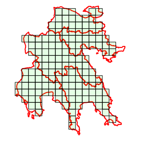

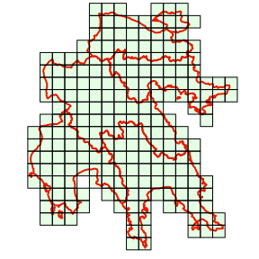

```r
# Η κλήση της EtrsTrasnform για αλλαγη του CRS
Π.ΠΕΛΟΠΟΝΝΗΣΟΥ.ETRS <- EtrsTransform(Π.ΠΕΛΟΠΟΝΝΗΣΟΥ)
par(mar = c(0.1, 0.1, 0.1, 0.1))
plot(Π.ΠΕΛΟΠΟΝΝΗΣΟΥ.ETRS, border = 2, lwd = 2)
plot(srf.grd.max, col = rgb(0, 1, 0, 0.1), add = TRUE)
plot(Π.ΠΕΛΟΠΟΝΝΗΣΟΥ.ETRS, border = 2, lwd = 2)
plot(srf.grd.prop, col = rgb(0, 1, 0, 0.1), add = TRUE)
```

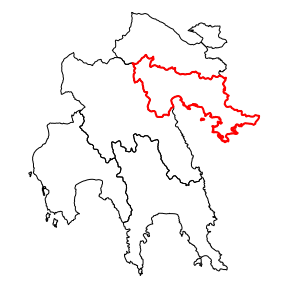

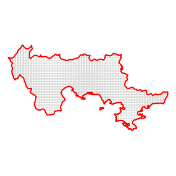

```r
par(mar = c(0.1, 0.1, 0.1, 0.1))
ΑΡΓΟΛΙΔΑ <- NUTS3_OCMG[which(!is.na(match(NUTS3_OCMG[["NAME"]], "Ν. ΑΡΓΟΛΙΔΟΣ"))),
    ]
plot(Π.ΠΕΛΟΠΟΝΝΗΣΟΥ)
plot(ΑΡΓΟΛΙΔΑ, add = TRUE, lwd = 2, border = 2)
# Εδώ καλείται η EtrsTransform απευθείας
ΑΡΓΟΛΙΔΑ.ETRS <- EtrsTransform(ΑΡΓΟΛΙΔΑ)
# Με την κλήση της etrsSourceSurface παράγεται η επιφανεια πηγή
source.surface <- etrsSourceSurface(input.surface = Π.ΠΕΛΟΠΟΝΝΗΣΟΥ.2001[3,
    ], over.method.type = "PropCal", surface.value.col = 4, cell.size = 1000)
plot(source.surface, col = rgb(0, 1, 0, 0.01), lwd = 0.5, border = "lightgrey")
plot(ΑΡΓΟΛΙΔΑ.ETRS, add = TRUE, lwd = 2, border = 2)
```

## Η Βοηθιτική επιφάνεια

Θα γίνει χρήση των δεδομένων CORINE 2000 δηλαδή των δεδομένων κάλυψη γης για την Ελλάδα και το έτος 2000, όπως διατίθενται από Ευρωπαϊκή Υπηρεσία Περιβάλλοντος . Τα δεδομένα αυτά μπορούν να μεταμορφωθούν από τον ισότοπο της [ΕΕΑ](http://www.eea.europa.eu/data-and-maps/data/corine-land-cover-2000-clc2000-seamless-vector-database-1#tab-interactive-maps-produced) και επιλέχθηκαν ως κατάλληλα από την άποψη της χρονικής κατανομής σε σχέση με το φαινόμενο (πληθυσμό 2001) που θέλουμε να ανακατανείμουμε. Για την προετοιμασία της επιφάνειας επίσης θα γίνει η χρήση της `etrsAncillarySurface`. Εδώ κρίνεται σκόπιμο να γίνουν ορισμένες επισημάνσεις στο χρήστη του πακέτου. Παρόλο που οι τρεις μέθοδοι δημιουργίας των επιφανειών `etrsSurface`, `etsrSourceSurface`, `etrsAncillarySurface` επί της ουσίας κάνουν ακριβώς τους ίδιους υπολογισμούς, και οι κλάσεις περιέχουν τα ίδια `@slots` και θα μπορούσε ο χρήστης να αποφασίζει για την “ορθή” χρήση τους η επιλογή αυτή έγινε για να καθοδηγήσει τον χρήστη για το πώς θα πρέπει να ενεργήσει. Θα γίνουμε πιο συγκεκριμένη στην πορεία ολοκλήρωσης του τρέχοντος παραδείγματος.

### Προετοιμασία των Δεδομένων

Εδώ ο χρήστης θα πρέπει να κάνει τις επιλογές *που στηρίζονται στην εμπιρεία του η/και την γνώση του* για το θέμα (Ως εκ τούτου η μέθοδος συχνά αναφέρεται ως Intelligent Dasymetric Maping. Ας δούμε τις κατηγορίες καλύψεων που περιέχονται στην Corine DB:

```r
data("CLC2000_CODES")
kable(head(CLC2000_CODES))
```

| Code_00 | DESCRIPTION |
| --- | --- |
| 111 | Συνεχής αστική οικοδόμηση |
| 112 | Διακεκομμένη αστική οικοδόμηση |
| 121 | Βιομηχανικές ή εμπορικές ζώνες |
| 122 | Οδικά σιδηροδρομικά δίκτυα και γειτνιάζουσα γη |
| 123 | Ζώνες λιμένων |
| 124 | Αεροδρόμια |
| … |  |

Είναι προφανές ότι για το παράδειγμα, ενδιαφέρουν μόνο οι δύο κατηγορίες 111 και 112 που σχετίζονται με την κατοικία. Αυτές θα μεταφορτώνουν από την ΕΕΑ αφού διατίθενται για μεταφόρτωση σε αρχεία .shp κατα τις προαναφερόμενες κατηγόρίες.

Με τον παρακάτω κώδικα θα μπορούσε κάποιος να δημιουργησει αν dataset με κάλυψη για όποια κατηγορία ή έτος απαιτείται για την ανάλυσή του. Παρατίθεται εδώ για να αποτελέσει οδηγό σε ενδεχομένη προετοιμασία άλλων δεδομένων από τον χρήστη.

```r
# Τα δύο .shp files περιέχονται στο folder corine
setwd(system.file("data/corine", package = "DasyMapR"))
# Με βάση τα όρια της περιοχής ...
bb <- bbox(ΑΡΓΟΛΙΔΑ.ETRS)
# διμιουργησε νέα .shp files που περιέχουν όσα δεδομένα χρειάζομαι
ogr2ogr(".", "clc_cliped", spat = c(bb[, 1], bb[, 2]))
dsn <- setwd("clc_cliped/")
# φόρτωσε τα ως SpatialPolygonsDataFrames
CLC2000_POLY_ARGOLIDA111 <- readOGR(".", "clc00_v2_code_111")
CLC2000_POLY_ARGOLIDA112 <- readOGR(".", "clc00_v2_code_112")
# και ένωσε τα
CLC2000.ARGOLIDA.RES <- rbind.SpatialPolygonsDataFrame(CLC2000_POLY_ARGOLIDA111,
    CLC2000_POLY_ARGOLIDA112, makeUniqueIDs = T)
# τέλος σώστα στο δίσκο ως dataset
setwd(system.file("data", package = "DasyMapR"))
# Αφαιρέθηκαν 2 πολύγωνα με πρόβλημα στην γεωμετρία
CLC2000.ARGOLIDA.RES <- CLC2000.ARGOLIDA.RES[-which(row.names(CLC2000.ARGOLIDA.RES) ==
    8), ]
CLC2000.ARGOLIDA.RES <- CLC2000.ARGOLIDA.RES[-which(row.names(CLC2000.ARGOLIDA.RES) %in%
    "01"), ]
devtools::use_data(CLC2000.ARGOLIDA.RES, overwrite = T)
```

Στο πακέτο `DasyMapR` υπάρχουν ήδη τα δεδομένα αυτά στο φάκελο `.\data` ως `datasets` που το συνοδεύουν.

```r
# Φορτώνουμε τα δεδομένα
data("CLC2000.ARGOLIDA.RES")
# Τι Περιέχει το σετ;
kable(head(CLC2000.ARGOLIDA.RES@data, 3))
```

|  | code_00 |
| --- | --- |
| 0 | 111 |
| 1 | 112 |
| 2 | 112 |

Και σε πιο άνθρωπο-φιλική μορφή

```r
ΠΕΡΙΟΧΕΣ.ΚΑΤΟΙΚΙΑΣ <- merge(x = CLC2000.ARGOLIDA.RES, y = CLC2000_CODES,
    by.x = "code_00", by.y = "Code_00")
kable(head(ΠΕΡΙΟΧΕΣ.ΚΑΤΟΙΚΙΑΣ@data, 3))
```

| code_00 | DESCRIPTION |
| --- | --- |
| 111 | Συνεχής αστική οικοδόμηση |
| 112 | Διακεκομμένη αστική οικοδόμηση |
| 112 | Διακεκομμένη αστική οικοδόμηση |

Θα θεωρήσουμε ότι ο λόγος της πυκνότητας $111 : 112 = 3 : 1$. δηλαδή ότι στις περιοχές με πυκνό αστικό ιστό ζουν 3 φορές περισσότερου άνθρωποι ανά μονάδα επιφανείας από ότι στις αραιά δομημένες περιοχές.

```r
par(mar = c(0.1, 0.1, 0.1, 0.1))
ReDens111 <- round(3/4, 2)
ReDens112 <- round(1/4, 2)
ΠΕΡΙΟΧΕΣ.ΚΑΤΟΙΚΙΑΣ@data[which(ΠΕΡΙΟΧΕΣ.ΚΑΤΟΙΚΙΑΣ@data[,
    "code_00"] == 111), "ReDens"] <- ReDens111
ΠΕΡΙΟΧΕΣ.ΚΑΤΟΙΚΙΑΣ@data[which(ΠΕΡΙΟΧΕΣ.ΚΑΤΟΙΚΙΑΣ@data[,
    "code_00"] == 112), "ReDens"] <- ReDens112
kable(head(ΠΕΡΙΟΧΕΣ.ΚΑΤΟΙΚΙΑΣ@data))
```

| code_00 | DESCRIPTION | ReDens |
| --- | --- | --- |
| 111 | Συνεχής αστική οικοδόμηση | 0.75 |
| 112 | Διακεκομμένη αστική οικοδόμηση | 0.25 |
| 112 | Διακεκομμένη αστική οικοδόμηση | 0.25 |
| 112 | Διακεκομμένη αστική οικοδόμηση | 0.25 |
| 112 | Διακεκομμένη αστική οικοδόμηση | 0.25 |
| 112 | Διακεκομμένη αστική οικοδόμηση | 0.25 |

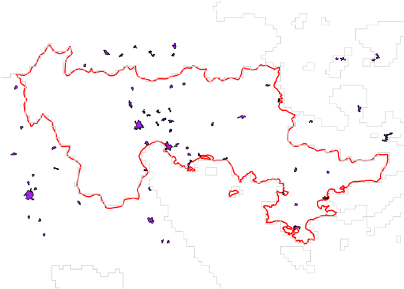

```r
plot(ΑΡΓΟΛΙΔΑ.ETRS, lwd = 2, border = 2)
plot(ΠΕΡΙΟΧΕΣ.ΚΑΤΟΙΚΙΑΣ, col = "purple", add = TRUE)
data("NUTSV9_LEAC")
plot(NUTSV9_LEAC, add = TRUE, border = "lightgrey")
```

Καλώντας την `etrsAncillarySurface` θα υπολογίσουμε την “σχετική πυκνότητα” του κάθε κελιού πλέον με βάση τις παραδοχές που έγιναν: *Όλος ο πλυθησμός της Αργολίδας το έτος 2001 κατοικουσε σις περιοχές με συνεχή και διακεκκομενη αστική δόμηση και με σχετική πυκνότητα μάλιστα 1:3.* Θα μπορούσαμε να συμπεριλάβουμε και άλλες περιοχές και να του αποδώσουμε κάποιο ποσοστό. (π.χ αγροτικές περιοχές 5 %)

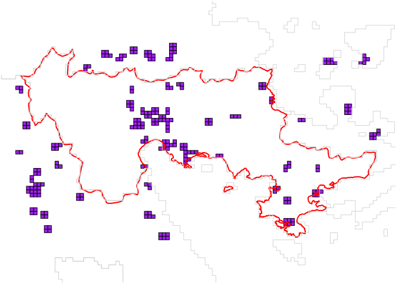

```r
par(mar = c(0.1, 0.1, 0.1, 0.1))
data("NUTSV9_LEAC")
the.ancillary.surface.bf <- etrsAncillarySurface(input.surface = ΠΕΡΙΟΧΕΣ.ΚΑΤΟΙΚΙΑΣ,
    over.method.type = "PropCal", surface.value.col = 3, cell.size = 1000, binary = FALSE)
plot(the.ancillary.surface.bf, col = "purple")
plot(ΑΡΓΟΛΙΔΑ.ETRS, add = TRUE, lwd = 2, border = 2)
plot(NUTSV9_LEAC, add = TRUE, border = "lightgrey")
```

```r
kable(head(the.ancillary.surface.bf@data))
```

|  | CELLCODE | EASTOFORIGIN | NORTHOFORIGIN | WCELLWEIGHT |
| --- | --- | --- | --- | --- |
| 1kmE5453N1679 | 1kmE5453N1679 | 5453000 | 1679000 | 0.002125 |
| 1kmE5454N1679 | 1kmE5454N1679 | 5454000 | 1679000 | 0.011550 |
| 1kmE5455N1679 | 1kmE5455N1679 | 5455000 | 1679000 | 0.006825 |
| 1kmE5453N1680 | 1kmE5453N1680 | 5453000 | 1680000 | 0.061250 |
| 1kmE5454N1680 | 1kmE5454N1680 | 5454000 | 1680000 | 0.073950 |
| 1kmE5455N1680 | 1kmE5455N1680 | 5455000 | 1680000 | 0.130800 |

```r
surface.detailed.table.bf <- readRDS(".surface.detailed.table.rds")
```

Θα επαναλάβουμε του ίδιους υπολογισμούς θέτοντας την παράμετρο `binary = TRUE` η οποία δίνει διαφοροποιημένα αποτελέσματα. Για να έχουμε αποτελέσματα θα πρέπει να θέσουμε την σχετική πυκνότητα σε 1. Στην ουσία λειτουργεί σαν την εφαρμογή της MaxArea στον υπολογισμό της βοηθητικής επιφάνειας. Πρακτικά σε φυσικούς όρους σημαίνει αν ένα κελί έχει την ιδιότητα να φιλοξενεί πληθυσμό με τιμή μεγαλύτερη από 50% Στην απεικόνιση που ακολουθεί μόνο τα κελιά με μοβ χρώμα έχουν τιμή για την `$WCELLWEGHT`

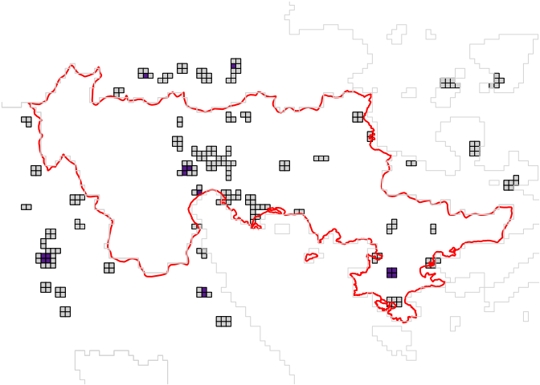

```r
par(mar = c(0.1, 0.1, 0.1, 0.1))
ΠΕΡΙΟΧΕΣ.ΚΑΤΟΙΚΙΑΣ@data[which(ΠΕΡΙΟΧΕΣ.ΚΑΤΟΙΚΙΑΣ@data[,
    "code_00"] == c(111, 112)), "ReDens"] <- 1
the.ancillary.surface.bt <- etrsAncillarySurface(input.surface = ΠΕΡΙΟΧΕΣ.ΚΑΤΟΙΚΙΑΣ,
    over.method.type = "PropCal", surface.value.col = 3, cell.size = 1000, binary = TRUE)
plot(the.ancillary.surface.bt, col = "purple4")
plot(the.ancillary.surface.bt[which(the.ancillary.surface.bt[["WCELLWEIGHT"]] ==
    0), ], col = "lightgrey", add = T)
plot(ΑΡΓΟΛΙΔΑ.ETRS, add = TRUE, lwd = 2, border = 2)
plot(NUTSV9_LEAC, add = TRUE, border = "lightgrey")
```

```r
kable(head(the.ancillary.surface.bt@data))
```

|  | CELLCODE | EASTOFORIGIN | NORTHOFORIGIN | WCELLWEIGHT |
| --- | --- | --- | --- | --- |
| 1kmE5453N1679 | 1kmE5453N1679 | 5453000 | 1679000 | 0 |
| 1kmE5454N1679 | 1kmE5454N1679 | 5454000 | 1679000 | 0 |
| 1kmE5455N1679 | 1kmE5455N1679 | 5455000 | 1679000 | 0 |
| 1kmE5453N1680 | 1kmE5453N1680 | 5453000 | 1680000 | 0 |
| 1kmE5454N1680 | 1kmE5454N1680 | 5454000 | 1680000 | 0 |
| 1kmE5455N1680 | 1kmE5455N1680 | 5455000 | 1680000 | 0 |

```r
surface.detailed.table.bt <- readRDS(".surface.detailed.table.rds")
```

Ας δούμε και τα αποτελέσματά του πίνακα καθώς και του προσωρινού αρχείου για τον έλεγχο τον υπολογισμών

```r
wd <- getwd()
setwd(wd)
kable(head(surface.detailed.table.bf))
```

| Row.names | CELLCODE | FEATURE | AREA | CELLSHARE | SURVALUE | CELLVALUE | SUMsΗAREi*Vi |
| --- | --- | --- | --- | --- | --- | --- | --- |
| 1kmE5413N1703 | 1kmE5413N1703 | 25 | 308220.7152 | 0.3082 | 0.25 | 0.07705 | 0.07705 |
| 1kmE5413N1721 | 1kmE5413N1721 | 50 | 20.2178 | 0 | 0.25 | 0 | 0.00000 |
| 1kmE5414N1703 | 1kmE5414N1703 | 25 | 200020.0517 | 0.2 | 0.25 | 0.05 | 0.05000 |
| 1kmE5414N1720 | 1kmE5414N1720 | 50 | 18780.6291 | 0.0188 | 0.25 | 0.0047 | 0.00470 |
| 1kmE5414N1721 | 1kmE5414N1721 | 50 | 456643.8894 | 0.4566 | 0.25 | 0.11415 | 0.11415 |
| 1kmE5415N1710 | 1kmE5415N1710 | 34 | 215448.6451 | 0.2154 | 0.25 | 0.05385 | 0.05385 |

## Ανακεφαλαιώνοντας

Είναι κατανοητό ότι και εδώ τα ζητήματα της κλίμακας του φαινομένου (κάλυψη) και της ανάλυσης (μέγεθος κελιού 1km) είναι σημαντικό να λαμβάνονται υπόψη από τον χρήστη για την παραγωγή αποτελεσμάτων αξιοποιήσιμων και “ρεαλιστικών” ώστε να διατηρείται η πληροφορία και να μην παράγεται νέα αλλά ψευδής. Για την συνέχεια του παραδείγματος θα επιλέξουμε την κατανομή που προέκυψε από την εφαρμογή της `etrsAncillarySurface(...,"PropCAl",...)` δηλαδή την *`the.ancillary.surface.bf`*

## Οι δασυμετρικοί υπολογισμοί

H μέθοδος για την εφαρμογή των δασυμετρικών υπολογισμών που θα κλιθεί είναι `etsrDasymetricSurface` και δέχεται ως ορίσματα μία επιφάνεια πηγή κλάσης `EtrsSourceSurface`την βοηθητική επιφάνεια κλάσης `EtrsAncillarySurface` και μία μεταβλητή logical `actuall.value` όπου εάν δοθεί η τιμή TRUE θα εφαρμοστεί η `ActuallVal2Density()` που η χρήση της εξηγήθηκε παραπάνω

```r
par(mar = c(0.1, 0.1, 0.1, 0.1))
dasymetric.surface <- EtrsDasymetricSurface(input.surface.grided = source.surface,
    ancillary.grided = the.ancillary.surface.bf, actuall.value = FALSE)
```

```
## ~~~ ETRS validity ~~~
```

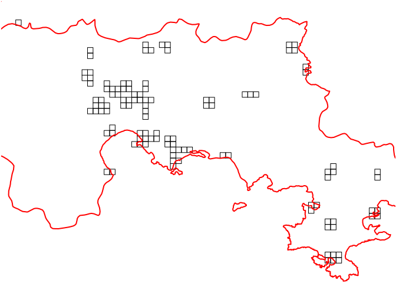

```r
plot(dasymetric.surface)
plot(ΑΡΓΟΛΙΔΑ.ETRS, add = T, border = "red", lwd = 2)
```

```r
kable(head(dasymetric.surface@data))
```

|  | CELLCODE | EASTOFORIGIN | NORTHOFORIGIN | CELLVALUE | WCELLWEIGHT | DASYCELL |
| --- | --- | --- | --- | --- | --- | --- |
| 94 | 1kmE5488N1683 | 5488000 | 1683000 | 26.65893 | 0.047100 | 739.05977 |
| 100 | 1kmE5489N1683 | 5489000 | 1683000 | 21.69835 | 0.006700 | 85.56922 |
| 106 | 1kmE5490N1683 | 5490000 | 1683000 | 47.46960 | 0.013925 | 389.06912 |
| 95 | 1kmE5488N1684 | 5488000 | 1684000 | 47.46960 | 0.042250 | 1180.47901 |
| 101 | 1kmE5489N1684 | 5489000 | 1684000 | 47.46960 | 0.070725 | 1976.07995 |
| 107 | 1kmE5490N1684 | 5490000 | 1684000 | 47.46960 | 0.015050 | 420.50199 |

## Η χρήση του NUTS και LAEA κανάβου

Το παράδειγμα που χρησιμοποιήθηκε όπως υπονοήθηκε δεν είναι αρκετά ακριβές αφού δεν χορηγήσαμε επαρκή στοιχεία τόσο για την κατανομή του πληθυσμού όσο και λόγω της μικρής κλίμακας των δεδομένων της κάλυψης. Θα μπορούσαμε να χρησιμοποιήσουμε δεδομένα από τις [UMZ200](http://www.eea.europa.eu/data-and-maps/data/urban-morphological-zones-2000-2)

Ειδικά για το πληθυσμό προσφέρονται δεδομένα για το πληθυσμό στον ETRS-LAEA κάναβο για τα έτη 2006 2011 που έχουν προκύψει από την εφαρμογή πιο περίπλοκων αλγορίθμων μπορούν να στο [ESPOn](http://database.espon.eu/db2/resource;jsessionid=0620e4b1ee3fe4232de4caab35e1?idCat=45).

```r
data("GEOSTAT_grid_EU_POP_2006_1k_V1_1_1")
kable(head(GEOSTAT_grid_EU_POP_2006_1k_V1_1_1))
```

| GRD_ID | POP_TOT | YEAR | METHD_CL | CNTR_CODE | DATA_SRC |
| --- | --- | --- | --- | --- | --- |
| 1kmN5142E2862 | 2 | 2006 | D | IS | AIT |
| 1kmN5141E2862 | 13 | 2006 | D | IS | AIT |
| 1kmN5141E2864 | 211 | 2006 | D | IS | AIT |
| 1kmN5140E2862 | 1 | 2006 | D | IS | AIT |
| 1kmN5139E2876 | 33 | 2006 | D | IS | AIT |
| 1kmN5138E2849 | 1 | 2006 | D | IS | AIT |

```r
GR_POP_2006 <- GEOSTAT_grid_EU_POP_2006_1k_V1_1_1[which(GEOSTAT_grid_EU_POP_2006_1k_V1_1_1[,
    "CNTR_CODE"] %in% "EL"), ]
```

Μία πιο προσεκτική ματιά σε αυτά τα δεδομένα δείχνει δεν ακολουθούν την προτεινόμενη κωδικοποίηση των κελιών της [INSPIRE Specification on Geographical Grid Systems](http://inspire.ec.europa.eu/index.cfm/pageid/241/documentid/3390) Για να τέτοια προβλήματα αναπτύχθηκε η μέθοδος `etrsReverseCellCode`.

```r
GR_POP_2006 <- as.data.frame(GR_POP_2006)
GR_POP_2006 <- etrsReverseCellCode(df = GR_POP_2006, cell.code.col = 1)
kable(head(GR_POP_2006))
```

|  | GRD_ID | POP_TOT | YEAR | METHD_CL | CNTR_CODE | DATA_SRC | CELLCODE |
| --- | --- | --- | --- | --- | --- | --- | --- |
| 1kmE5663N2213 | 1kmN2213E5663 | 304 | 2006 | D | EL | AIT | 1kmE5663N2213 |
| 1kmE5671N2213 | 1kmN2213E5671 | 155 | 2006 | D | EL | AIT | 1kmE5671N2213 |
| 1kmE5666N2212 | 1kmN2212E5666 | 578 | 2006 | D | EL | AIT | 1kmE5666N2212 |
| 1kmE5685N2212 | 1kmN2212E5685 | 89 | 2006 | D | EL | AIT | 1kmE5685N2212 |
| 1kmE5687N2211 | 1kmN2211E5687 | 4 | 2006 | D | EL | AIT | 1kmE5687N2211 |
| 1kmE5686N2210 | 1kmN2210E5686 | 611 | 2006 | D | EL | AIT | 1kmE5686N2210 |

Και για να απεικονισθούν τα δεδομένα μας στη μορφή του κανάβου μπορούμε να καλέσουμε την `EtrsGrid` και στην συνέχεια θα συγχωνεύσουμε τα πολύγωνα με τις εγγραφές στο data frame με του κωδικούς των κελλιών (`row.names,"ID"`(),ID).

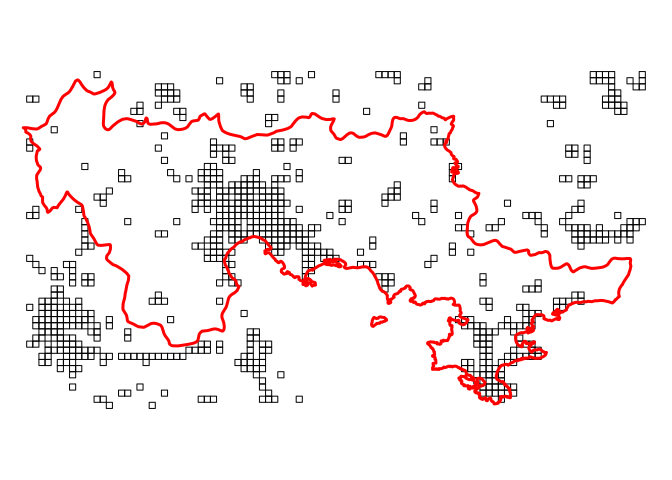

```r
par(mar = c(0.1, 0.1, 0.1, 0.1))
GR251 <- NUTSV9_LEAC[which(!is.na(match(NUTSV9_LEAC[["N3CD"]], "GR251"))), ]
GR251 <- EtrsTransform(GR251)
GR251.grd <- etrsGrid(GR251, cell.size = 1000)
GR251.grd <- merge(GR251.grd, GR_POP_2006, by = 0, all = F)
plot(GR251.grd)
plot(ΑΡΓΟΛΙΔΑ.ETRS, add = TRUE, border = 2, lwd = 3)
```

Όπως αναφέρθηκε τα διοικητικά όρια συχνά αλλάζουν τέτοιο παράδειγμα είναι η περίπτωση του Ευρωπαϊκού χώρου όπου το ιστορικό των [αλλαγων](http://ec.europa.eu/eurostat/web/nuts/history) συχνά δυσκολεύει την χρήση και σύγκριση των διαθέσιμων δεδομένων. Τα γεωγραφικά όρια μπορούν να μεταμορφωθούν από το της [EUROSTAT](http://ec.europa.eu/eurostat/web/gisco/geodata/reference-data/administrative-units-statistical-units/nuts#nuts13) Ας δούμε κατ’ αρχήν τις αλλαγές των ορίων στην υπό μελέτη περιοχή την Αργολίδα :

Φορτώνουμε τα δεδομένα και τα :

```r
par(mar = c(0.1, 0.1, 0.1, 0.1))
# Όρια NUTS 2006
GR25 <- NUTSV9_LEAC[which(!is.na(match(NUTSV9_LEAC[["N2CD"]], "GR25"))), ]
kable(head(GR25@data))
```

|  | NUTS3ID | NUFTTP | N0CD | N1CD | N2CD | N3CD | N0NME | N0NM | N1NM | N2NM | N3NM | N2_3CD |
| --- | --- | --- | --- | --- | --- | --- | --- | --- | --- | --- | --- | --- |
| 1312 | 1413 | M | GR | GR2 | GR25 | GR253 | GR GREECE | GR ELLADA | GR2 KENTRIKI ELLADA | GR25 Peloponnisos | GR253 Korinthia | GR25 |
| 1319 | 1422 | M | GR | GR2 | GR25 | GR252 | GR GREECE | GR ELLADA | GR2 KENTRIKI ELLADA | GR25 Peloponnisos | GR252 Arkadia | GR25 |
| 1327 | 1438 | M | GR | GR2 | GR25 | GR251 | GR GREECE | GR ELLADA | GR2 KENTRIKI ELLADA | GR25 Peloponnisos | GR251 Argolida | GR25 |
| 1329 | 1442 | M | GR | GR2 | GR25 | GR254 | GR GREECE | GR ELLADA | GR2 KENTRIKI ELLADA | GR25 Peloponnisos | GR254 Lakonia | GR25 |
| 1334 | 1451 | M | GR | GR2 | GR25 | GR255 | GR GREECE | GR ELLADA | GR2 KENTRIKI ELLADA | GR25 Peloponnisos | GR255 Messinia | GR25 |

```r
# Νέα όρια NUTS 2013
data("NUTS_2013_01M_EL")
kable(head(NUTS_2013_01M_EL@data))
```

|  | NUTS_ID | STAT_LEVL_ | SHAPE_AREA | SHAPE_LEN |
| --- | --- | --- | --- | --- |
| 667 | EL522 | 3 | 0.3924027 | 4.937318 |
| 668 | EL523 | 3 | 0.2700854 | 3.152490 |
| 669 | EL524 | 3 | 0.2679729 | 3.318840 |
| 670 | EL525 | 3 | 0.1616531 | 2.621749 |
| 671 | EL631 | 3 | 0.5604019 | 6.666641 |
| 672 | EL632 | 3 | 0.3360470 | 3.150293 |

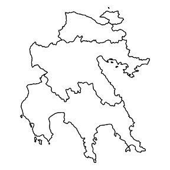

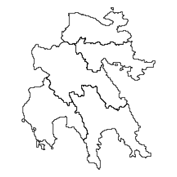

```r
NUTS_2013_01M_65 <- EtrsTransform(NUTS_2013_01M_EL[grep("^EL65", NUTS_2013_01M_EL[["NUTS_ID"]]),
    ])
plot(NUTS_2013_01M_65)
plot(GR25)
```

Για όποιον ενδιαφέρεται για δεδομένα κοινωνικό-οικονομικά, περιβαλλοντικά κ.λ.π. ήδη γνωρίζει ότι μια σημαντική πηγή στοιχείων είναι [EurostatDatabase](http://ec.europa.eu/eurostat/) Με την χρήση του `package eurostat` μπορούμε να συνεχίσουμε την ανάλυση μας και να απεικονίσουμε κοινωνικό - οικονομικά δεδομένα στον κάναβο. Π.Χ. μπορούμε να κατεβάσουμε δεδομένα για το ακαθάριστο εθνικό προϊόν ανά κάτοικο και να τα προβάλουμε στο κελί επιμερίζοντας τα με βάση τον αριθμό κατοίκων ανά κελί από τα προηγούμενα βήματα.

Ας αναζητήσουμε κάποια στοιχεία από την Eurostat. Θα κάνουμε την αναζήτηση με βάση τo γεωγραφικό επίπεδο αναφοράς (NUTS3)

```r
info <- search_eurostat("NUTS 3")
kable(info[c(23:30), c(1, 2)])
```

|  | title | code |
| --- | --- | --- |
| 215 | Private households by composition, age group of children and NUTS 3 regions | cens_01rhagchi |
| 217 | Dwellings by type of housing, building and NUTS 3 regions | cens_01rdhh |
| 218 | Persons by type of building and NUTS 3 regions | cens_01rdbuild |
| 222 | Average annual population to calculate regional GDP data (thousand persons) by NUTS 3 regions | nama_10r_3popgdp |
| 223 | Gross domestic product (GDP) at current market prices by NUTS 3 regions | nama_10r_3gdp |
| 226 | Gross value added at basic prices by NUTS 3 regions | nama_10r_3gva |
| 229 | Employment (thousand persons) by NUTS 3 regions | nama_10r_3empers |
| 238 | Gross domestic product (GDP) at current market prices by NUTS 3 regions | nama_r_e3gdp |

επιλέγονται δεδομένα για το ακαθάριστο εθνικό προϊόν του 2001 (Gross domestic product (GDP) at current market prices by NUTS 3 regions) και εiδικότερα για την περιοχή ενδιαφέροντος. H Επόμενη γραμμή χρειάζεται σύνδεση και δεν θα τρέξει αν δεν υπάρχει οπότε στο παράδειγμά μας

```r
# nama_10r_3gdp <- get_eurostat(id = 'nama_10r_3gdp' ,filters =
# list(time=2006),time_format = 'num')
```

Τα δεδομένα αυτά έχουν ήδη και περιέχονται στο πακέτο. Έτσι ι τα φορτώνονται από το /data με την χρήση `data()`

```r
data("nama_10r_3gdp")
dat <- nama_10r_3gdp
```

α περιορίσουμε την εργασία εδώ για λόγους οικονομίας στον νομό Αργολίδας (και “αναγκαστικά” και Αργολίδας)

```r
GDP651_2006 <- dat[grep("^EL651", dat$geo), ]
kable(label_eurostat(GDP651_2006))
```

|  | unit | geo | time | values |
| --- | --- | --- | --- | --- |
| 723 | Euro per inhabitant | Argolida, Arkadia | 2001 | 12800 |
| 2553 | Euro per inhabitant in percentage of the EU average | Argolida, Arkadia | 2001 | 63 |
| 4383 | Million euro | Argolida, Arkadia | 2001 | 2426 |
| 6213 | Million PPS (purchasing power standard) | Argolida, Arkadia | 2001 | 3103 |
| 8043 | Purchasing Power Standard per inhabitant | Argolida, Arkadia | 2001 | 16300 |
| 9873 | Purchasing Power Standards per inhabitant in percentage of the EU average | Argolida, Arkadia | 2001 | 80 |

Για να γίνει γεωναφορά των δεδομένων αυτών θα χρησιμοποιήσουμε τα όρια όπως αυτά παρέχονται [EUROSTAT](http://ec.europa.eu/eurostat/web/gisco/geodata/reference-data/administrative-units-statistical-units/nuts#nuts13).

```r
par(mar = c(0.1, 0.1, 0.1, 0.1))
NUTS_2013_01M_651 <- EtrsTransform(NUTS_2013_01M_EL[grep("^EL651", NUTS_2013_01M_EL[["NUTS_ID"]]),
    ])
kable(NUTS_2013_01M_651@data)
```

|  | NUTS_ID | STAT_LEVL_ | SHAPE_AREA | SHAPE_LEN |
| --- | --- | --- | --- | --- |
| 673 | EL651 | 3 | 0.670281 | 7.572672 |

Αρχικά γίνεται η γεωαναφορά των στοιχείων

```r
NUTS_2013_01M_651 <- merge(NUTS_2013_01M_651, GDP651_2006[1, ], by.x = "NUTS_ID",
    by.y = "geo", all = FALSE)
```

H χρήση της `merge` ενδεχομένως να προκαλέσει αλλαγή στα `rownames` του `dataframe` οπότε έστω και προληπτικά τα διορθώνουμε

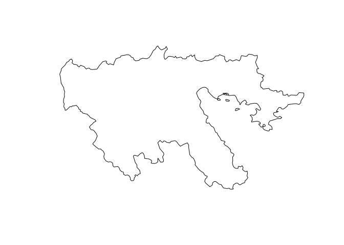

```r
row.names(NUTS_2013_01M_651@data) <- sapply(slot(NUTS_2013_01M_651, "polygons"),
    function(x) slot(x, "ID"))
plot(NUTS_2013_01M_651)
```

```r
kable(NUTS_2013_01M_651@data)
```

[output not shown]

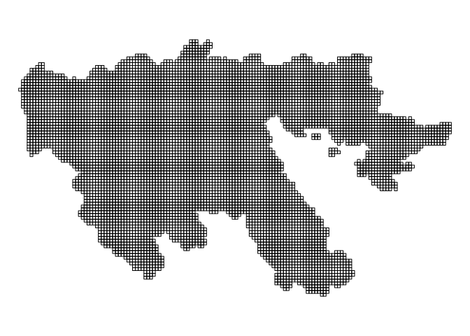

```r
par(mar = c(0.1, 0.1, 0.1, 0.1))
NUTS_2013_01M_651_GDP <- etrsSourceSurface(input.surface = NUTS_2013_01M_651,
    over.method.type = "PropCal", surface.value.col = 7, cell.size = 1000)
plot(NUTS_2013_01M_651_GDP)
```

```r
kable(head(NUTS_2013_01M_651_GDP@data))
```

|  | CELLCODE | EASTOFORIGIN | NORTHOFORIGIN | CELLVALUE |
| --- | --- | --- | --- | --- |
| 1kmE5468N1643 | 1kmE5468N1643 | 5468000 | 1643000 | 7.68 |
| 1kmE5469N1643 | 1kmE5469N1643 | 5469000 | 1643000 | 24.32 |
| 1kmE5463N1644 | 1kmE5463N1644 | 5463000 | 1644000 | 2.56 |
| 1kmE5464N1644 | 1kmE5464N1644 | 5464000 | 1644000 | 3031.04 |
| 1kmE5465N1644 | 1kmE5465N1644 | 5465000 | 1644000 | 5710.08 |
| 1kmE5466N1644 | 1kmE5466N1644 | 5466000 | 1644000 | 6620.16 |

Η προηγούμενη επιφάνεια `dasymetric.surface` που υπολογίστηκε ως Δασυμετρική επιφάνεια τώρα θα μετατραπεί σε βοηθητική επιφάνεια και θα χρησιμοποιεί για την κατανομή της τιμής της GDP. Σε αυτήν απεικονιζόταν ο αριθμός των κατοίκων ανά κελί που είχε την ιδιότητα του συνεχούς ή αστικού ιστού

```r
kable(head(dasymetric.surface@data))
POP_2001_ancillary <- etrsDasymetric2Ancillary(dasymetric.surface)
row.names(POP_2001_ancillary@data) <- sapply(slot(POP_2001_ancillary, "polygons"),
    function(x) slot(x, "ID"))
```

[output not shown]

Τέλος με την κλίση της `etrsPropWeightedValue` θα υπολογιστεί η τιμή του ακαθάριστου προϊόντος σε κάθε κελί

```r
par(mar = c(0.1, 0.1, 0.1, 0.1))
DASY_GPD <- etrsPropWeightedValue(input.surface.grided = NUTS_2013_01M_651_GDP,
    ancillary.grided = POP_2001_ancillary)
```

```
## ~~~ ETRS validity ~~~
```

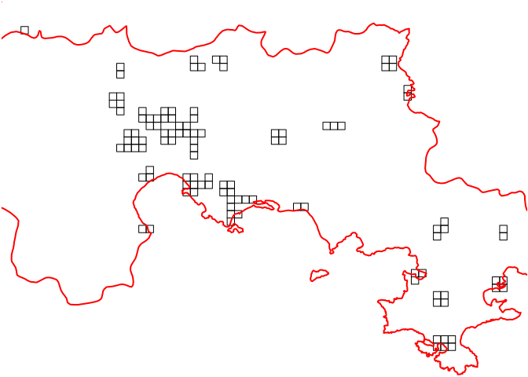

```r
plot(DASY_GPD)
plot(ΑΡΓΟΛΙΔΑ.ETRS, add = T, border = 2, lwd = 2)
```

```r
kable(head(DASY_GPD))
```

|  | CELLCODE | EASTOFORIGIN | NORTHOFORIGIN | CELLVALUE | WCELLWEIGHT | DASYCELL |
| --- | --- | --- | --- | --- | --- | --- |
| 93 | 1kmE5488N1683 | 5488000 | 1683000 | 7016.96 | 739.05977 | 5185952.8 |
| 99 | 1kmE5489N1683 | 5489000 | 1683000 | 2048.00 | 85.56922 | 175245.8 |
| 105 | 1kmE5490N1683 | 5490000 | 1683000 | 12800.00 | 389.06912 | 4980084.7 |
| 94 | 1kmE5488N1684 | 5488000 | 1684000 | 12277.76 | 1180.47901 | 14493637.9 |
| 100 | 1kmE5489N1684 | 5489000 | 1684000 | 12029.44 | 1976.07995 | 23771135.2 |
| 106 | 1kmE5490N1684 | 5490000 | 1684000 | 12800.00 | 420.50199 | 5382425.5 |

Τέλος η μετατροπή των αποτελέσματα σε raster θα έκανε τα ευκολότερα διαθέσιμα για χρήση. Θα χρησιμοποιήσουμε την `etrsDasymetric2Raster`που εξαρτάται απο το πακέτο `raster` για να επιτύχουμε το ζητούμενο αποτέλεσμα

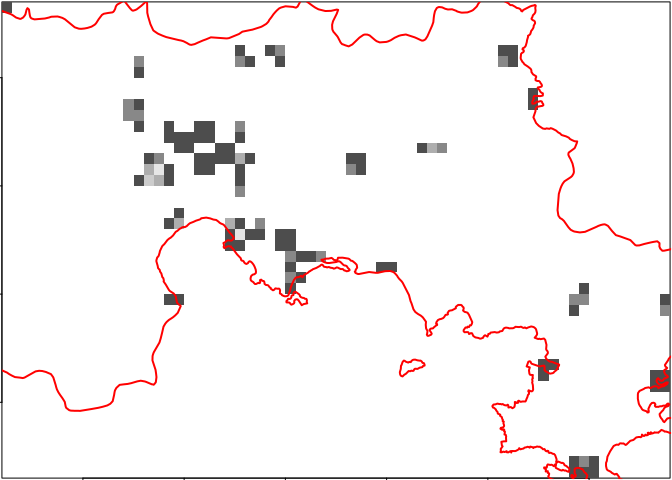

```r
par(mar = c(0.1, 0.1, 0.1, 0.1))
DASY_GPD_RASTER <- etrsDasymetric2Raster(dasymetric.surface = DASY_GPD)
rw.colors <- grey.colors
image(DASY_GPD_RASTER, col = rw.colors(5))
plot(ΑΡΓΟΛΙΔΑ.ETRS, add = T, border = 2, lwd = 2)
```